# Internships and Majors

Thanh Trinh

April 18, 2018

# Introduction

We are interested in which variables affect the starting salary for an initial job offer the most. We have developed the following questions that we will explore:

- How much does having an internship affect your starting salary
- Does it matter if the internship is related to the respective major? / Are those that get internships more likely to choose a post grad job related to their major?
- How much does one internship differ from many?

We have realized that there is a large sum of “dirty” data, and will thus do some cleanup. Some hourly wages appear to be above $40-$45, which seems very unreasonable for even out of state internships in high cost-of-living states such as California. That being said, I will filter out the results greater than $40/h.

## How many internships did most students have?

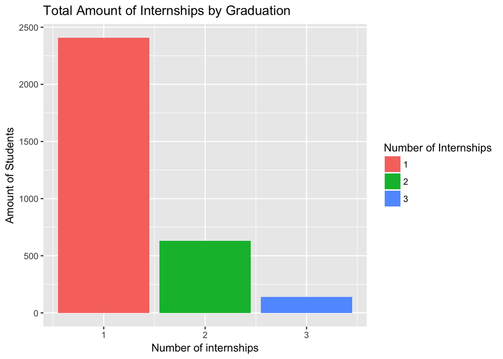

## How does the salary differ between each amount of internships?

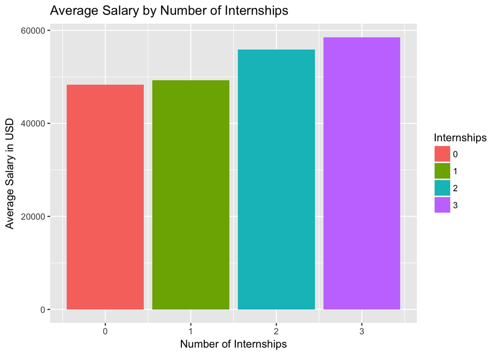

As per the graphs, we can see that there is not a substantial change from having no internships to having one, but the difference between 0 to 2/3 is pretty large. Someone with 3 internships will make $10208 more on average, which is a 21.1363% increase.

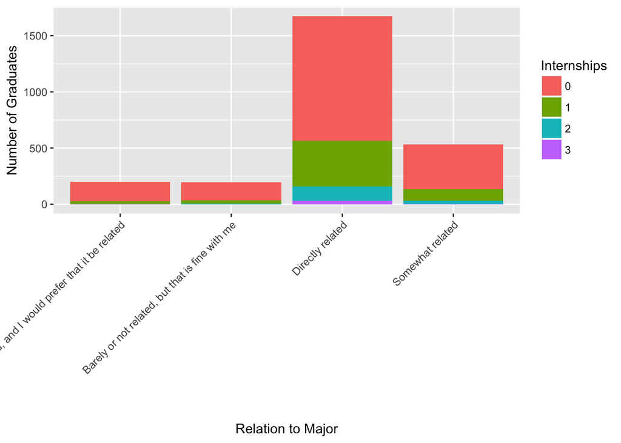

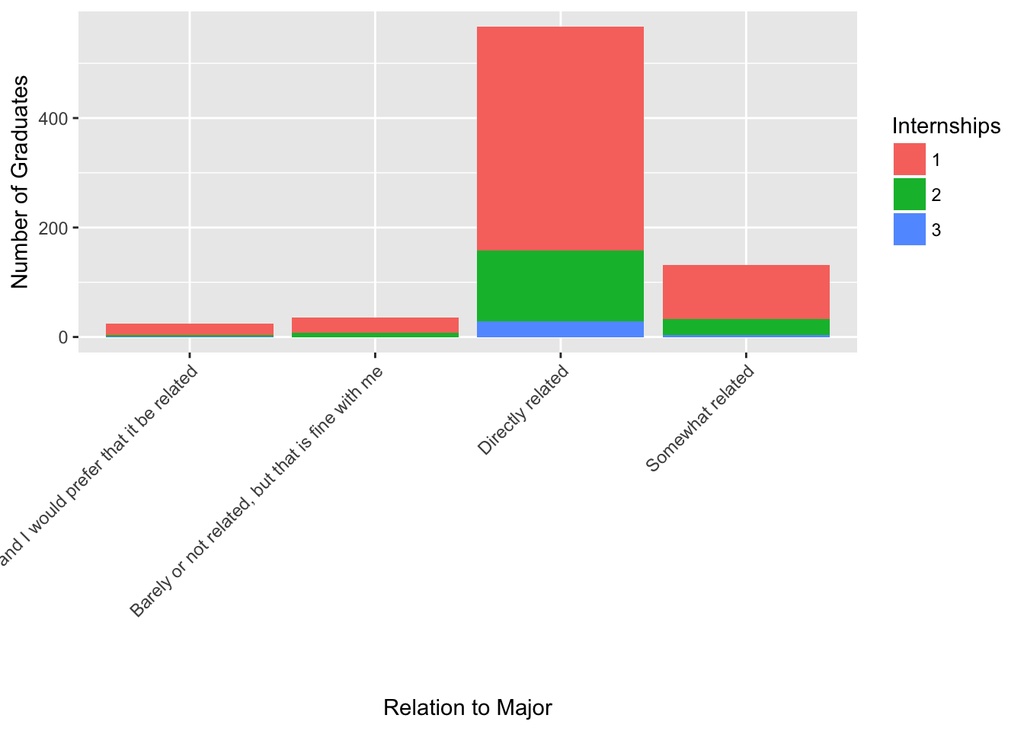

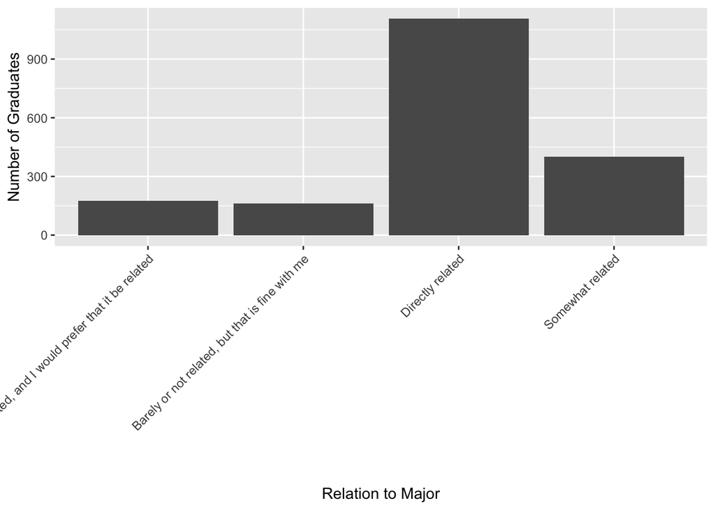

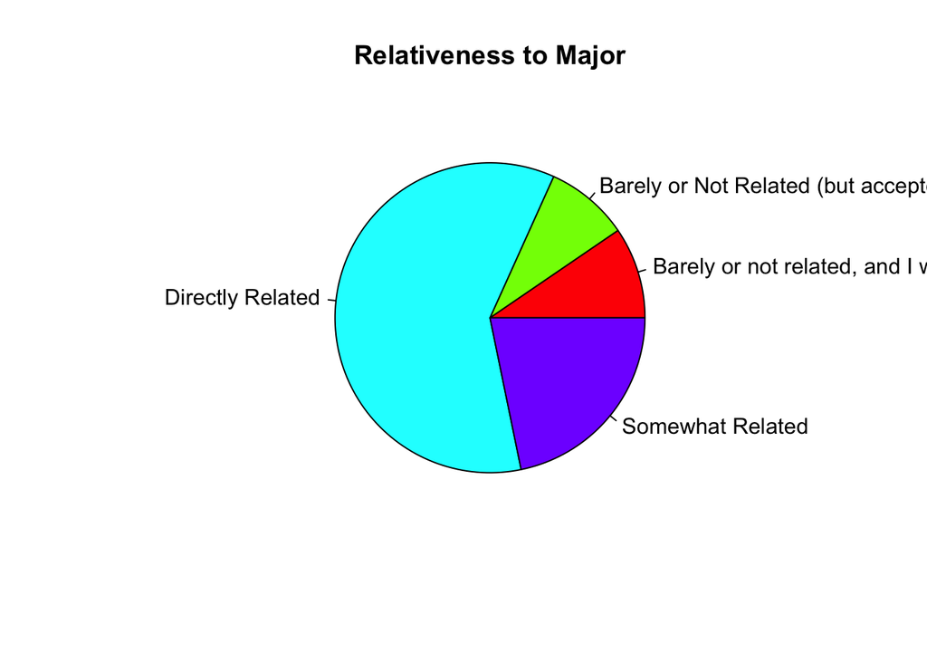